# Algorithms

Zelos Zhu

April 6, 2016

Coordinate descent is an optimization algorithm. It can be used to find a local minimum of a function. To perform coordinate descent, you perform a line search along one coordinate direction to find the value that minimizes the function in that direction while the other values are held constant. Once the value for that direction is updated, you perform the same operation for the other coordinate directions. This repeats until it has been updated for all coordinate directions, at which point the cycle repeats.

Thus for a function of two variables $f(x,y)$, a simple version of the algorithm can be described as follows:

1. Start with some initial values of $x$ and $y$. This is time 0, so we have $x^{(0)}$ and $y^{(0)}$.
2. Iterate:
   1. Update $x^{(t+1)}$ to be the value of $x$ that minimizes $f(x,y = y^{(t)})$
   2. Update $y^{(t+1)}$ to be the value of $y$ that minimizes $f(x = x^{(t)},y)$
3. Stop when some convergence criterion has been met.

The “tricky” part of the algorithm is finding the value that minimizes the function along one of the directions.

## Golden Section Search Method (with Video)

This unidimensional minimization be done in one of many ways, but for our purposes, we will use the golden section search method.

The premise of how the golden section search works is summarized very nicely in this video from CUBoulderComputing: https://vimeo.com/86277921

I will provide the code for the golden section search method here. This is a modified version of Eric Cai’s code (https://chemicalstatistician.wordpress.com). It has been modified so that the locations of x1 and x2 match the CUBoulderComputing video

```r
##### A modifcation of code provided by Eric Cai
golden = function(f, lower, upper, tolerance = 1e-5)
{
   golden.ratio = 2/(sqrt(5) + 1)

   ## Use the golden ratio to find the initial test points
   x1 <- lower + golden.ratio * (upper - lower)
   x2 <- upper - golden.ratio * (upper - lower)

   ## the arrangement of points is:
   ## lower ----- x2 --- x1 ----- upper

   ### Evaluate the function at the test points
   f1 <- f(x1)
   f2 <- f(x2)

   while (abs(upper - lower) > tolerance) {
        if (f2 > f1) {
        # the minimum is to the right of x2
        lower <- x2  # x2 becomes the new lower bound
        x2 <- x1     # x1 becomes the new x2
        f2 <- f1     # f(x1) now becomes f(x2)
        x1 <- lower + golden.ratio * (upper - lower)
        f1 <- f(x1)  # calculate new x1 and f(x1)
        } else {
        # then the minimum is to the left of x1
        upper <- x1  # x1 becomes the new upper bound
        x1 <- x2     # x2 becomes the new x1
        f1 <- f2
        x2 <- upper - golden.ratio * (upper - lower)
        f2 <- f(x2)  # calculate new x2 and f(x2)
        }
    }
    (lower + upper)/2 # the returned value is the midpoint of the bounds
}
```

We can thus use the golden search to find the minimizing value of a function. For example, the function $f(x) = (x - 3)^2$ has a minimum value at $x = 3$.

```r
f <- function(x){ (x - 3)^2 }
golden(f, 0, 10)
```

```
## [1] 3.000001
```

# Coordinate Descent

$g(x,y) = 5 x ^ 2 - 6 x y + 5 y ^ 2$

```r
#Generate a function, some data, and a contour map
g <- function(x,y) {
    5 * x ^ 2 - 6 * x * y + 5 * y ^ 2
    }
x <- seq(-1.5,1.5, len=100)
y <- seq(-1.5,1.5, len=100)
z <- outer(x,y,g)
x_i <- -1.5
y_i <- -1.5
```

**Apply the Coordinate Descent**

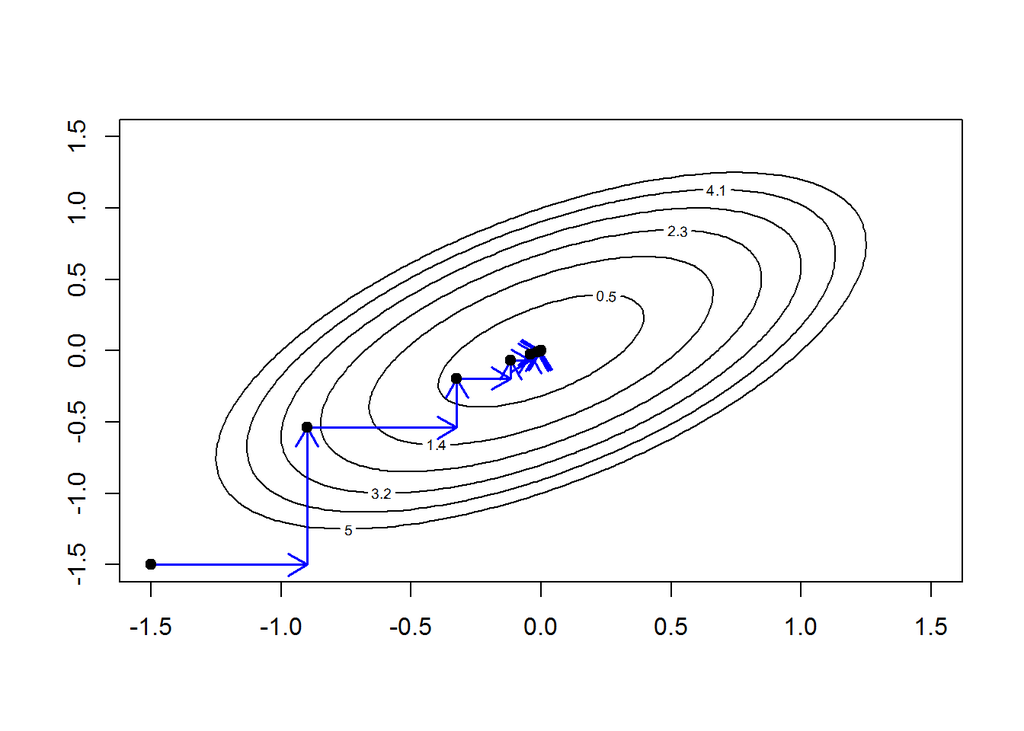

```r
#create unidimensional functions, that will draw from a matrix of values that will continually be edited
fx<-function(x){
  g(x,y_i[i])
}
fy<-function(y){
  g(x_i[i+1],y)
}
contour(x,y,z, levels = seq(.5,5,by=.9)) # code to plot contour lines
#loop for adding values, x first then y, draw the arrows while we do the loop
for(i in 1:15){
  x_i[i+1]<-golden(fx,x_i[i],1.5)
  arrows(x_i[i], y_i[i], x_i[i+1], y_i[i],col="blue",code=2,length=0.15,lty=1,lwd=1.5,angle=30)
  y_i[i+1]<-golden(fy,y_i[i],1.5)
  arrows(x_i[i+1], y_i[i], x_i[i+1], y_i[i+1],col="blue",code=2,length=0.15,lty=1,lwd=1.5,angle=30)
}
points(x_i,y_i,pch=19)
```

# Gradient Descent

Using the same function, but different starting points

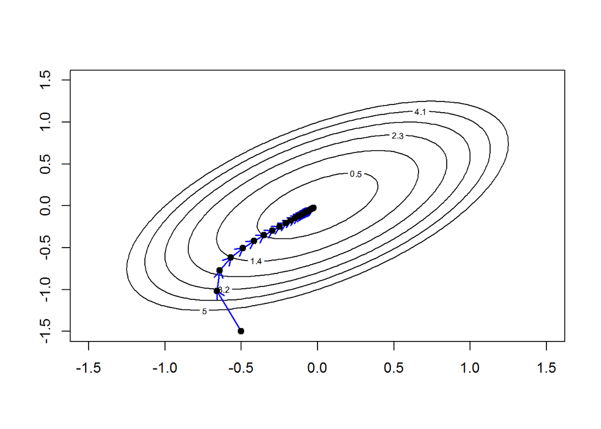

```r
g <- function(x,y) {
    5 * x ^ 2 - 6 * x * y + 5 * y ^ 2
    }
x <- seq(-1.5,1.5, len=100)
y <- seq(-1.5,1.5, len=100)
z <- outer(x,y,g)
contour(x,y,z, levels = seq(.5,5,by=.9)) # code to plot contour lines
x_i <- -0.5
y_i <- -1.5
alpha = 0.04

#solve for the gradient and put them into functions
x_grad<-function(x,y){
  10*x-6*y
}

y_grad<-function(x,y){
  10*y-6*x
}

#after figuring out how many loops it takes to converge, I set n to that number so my end matrix doesn't have any NA's
n<-21

#matrices to keep track of the points and gradients at those points
betamat <- matrix(NA, nrow=n+1, ncol=2)
betamat[1,1] <- x_i
betamat[1,2] <- y_i
betastep <- matrix(NA, nrow=n+1, ncol=2)
betastep[1,1] <- x_grad(x_i,y_i)
betastep[1,2] <- y_grad(x_i,y_i)

#for loop to descend along gradient, draws arrows as we go down as I did in Task 1
for(i in 1:n){
    b0step <- alpha * x_grad(x_i[i],y_i[i])
    b1step <- alpha * y_grad(x_i[i],y_i[i])
    x_i[i+1] <- x_i[i] - b0step
    y_i[i+1] <- y_i[i] - b1step
    betamat[i+1,1] <- x_i[i+1]
    betamat[i+1,2] <- y_i[i+1]
    arrows(betamat[i+1,1], betamat[i+1,2], betamat[i,1], betamat[i,2], col="blue",code=1,length=0.1,lty=1,lwd=1.5,angle=30)
    betastep[i+1,1] <- b0step
    betastep[i+1,2] <- b1step
    converge_x <- betastep[i,1]-betastep[i+1,1]
    converge_y <- betastep[i,2]-betastep[i+1,2]
    if( abs(converge_x) < 0.001 | abs(converge_y) < 0.001) {
      break
    }
}
points(betamat[,1],betamat[,2],pch=19)
```

Point converges in about “21 steps”.

# K-Means Clustering

Generate some data from a multivariate normal distribution

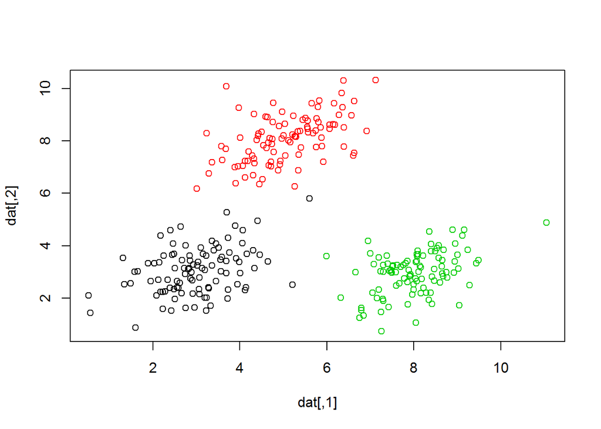

```r
set.seed(2016)
library(mvtnorm)
cv <- matrix(c(.8,.4,.4,.8), ncol=2)
j <- rmvnorm(100, mean = c(3,3), sigma = cv)
k <- rmvnorm(100, mean = c(5,8), sigma = cv)
l <- rmvnorm(100, mean = c(8,3), sigma = cv)
dat <- rbind(j,k,l)
true_groups <- as.factor(c(rep("j",100),rep("k",100),rep("l",100) ))
plot(dat, col=true_groups)
```

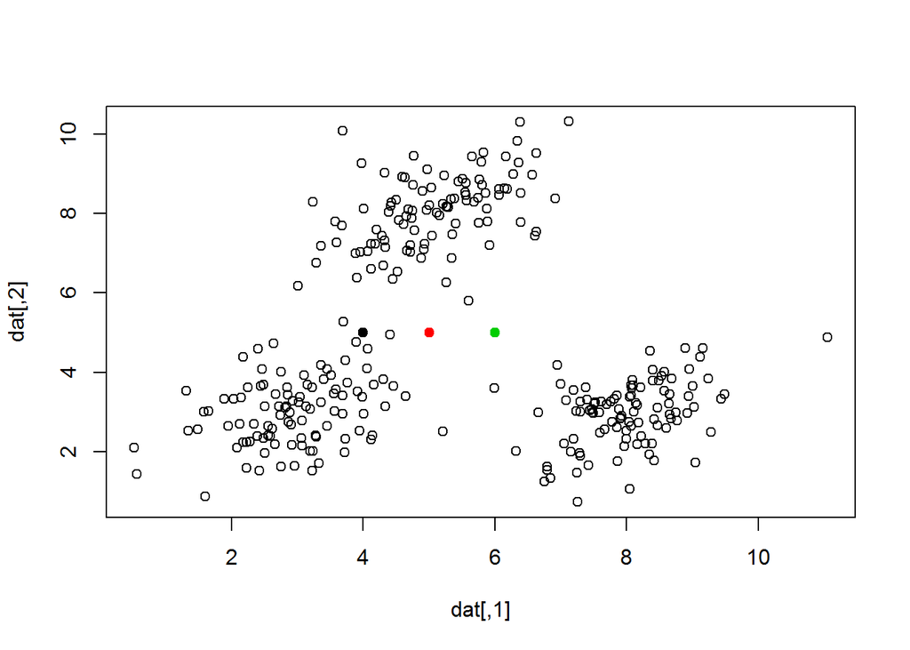

```r
means <- rbind(c(4,5), c(5,5), c(6,5)) # matrix of starting means
groupings = as.factor(rep(1,300))  #initial groupings that you will need to update
plot(dat, col = groupings)  # initial plot
points(means, col = as.factor(1:3), pch = 19) # add dots for the means
```

**The algorithm at practice**

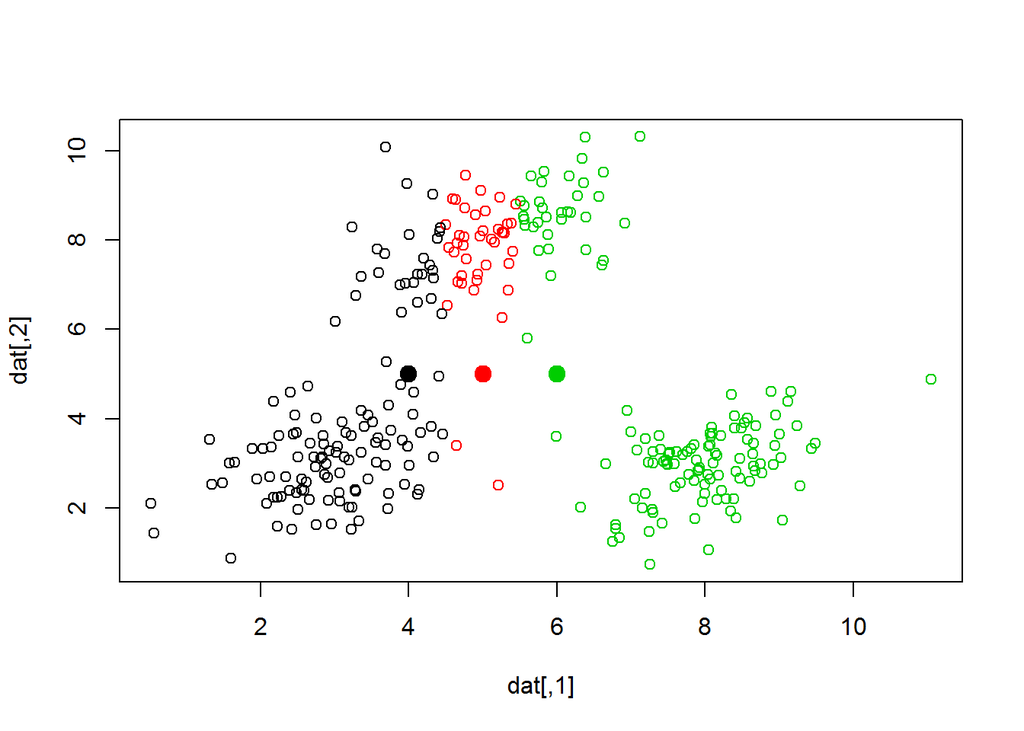

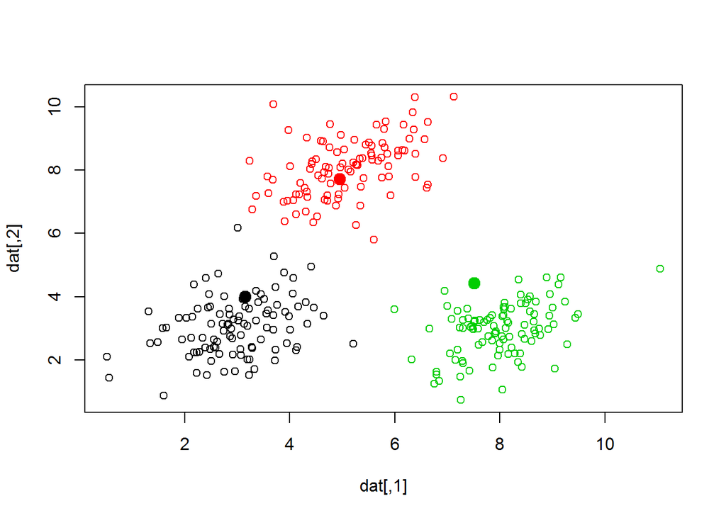

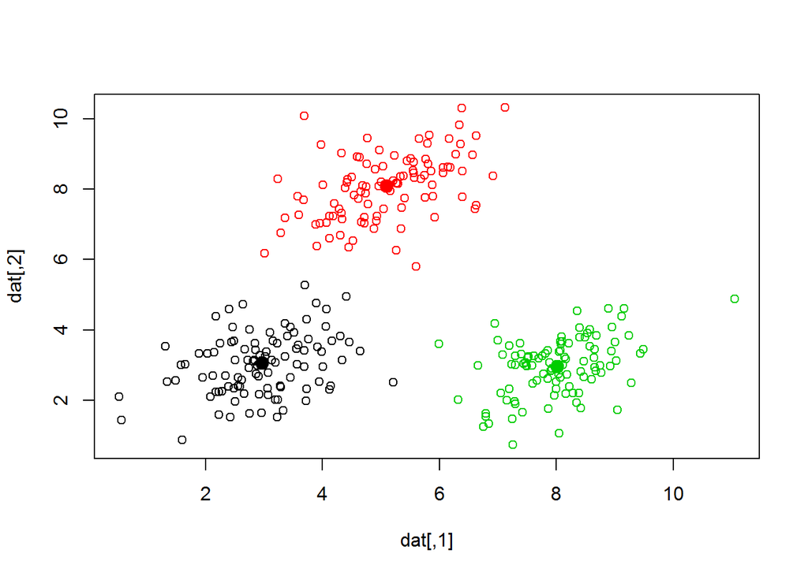

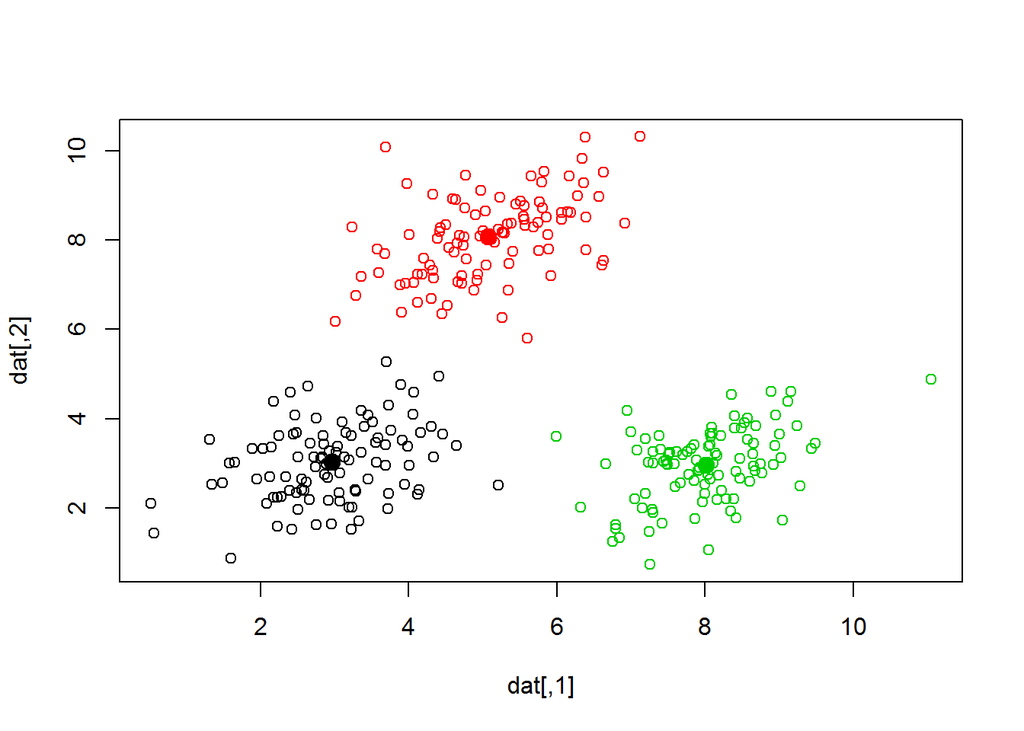

```r
#create a distance function that returns one of three values, 1 for the black point, 2 for the red point, 3 for the green point
dist<-function(dat,means){
  dist1<-sqrt((dat[i,1]-means[1,1])^2+(dat[i,2]-means[1,2])^2)
  dist2<-sqrt((dat[i,1]-means[2,1])^2+(dat[i,2]-means[2,2])^2)
  dist3<-sqrt((dat[i,1]-means[3,1])^2+(dat[i,2]-means[3,2])^2)
  small<-min(c(dist1,dist2,dist3))
  if (small==dist1)
  {
    return(1)
  }
  if (small==dist2)
  {
    return(2)
  }
  if (small==dist3)
  {
    return(3)
  }
}

for(j in 1:6){
  cluster<-as.matrix(NA,nrow=300,ncol=1)
  for(i in 1:300){
    cluster[i]<-dist(dat,means)
  }
    dat2<-cbind(dat,cluster)
    groups<-as.factor(cluster)
    plot(dat,col=groups)
    points(means,col=as.factor(1:3),pch=19,cex=1.5)
    dat2<-as.data.frame(dat2)
    meansx<-tapply(dat2$V1,dat2$cluster,FUN=mean)
    meansy<-tapply(dat2$V2,dat2$cluster,FUN=mean)
    means<-t(rbind(meansx,meansy))
}
```

```r
#confusion matrix, 1 error and it is the a point near (5.8,6) where it is black in the original but is blatantly closer to the top cluster
print(table(groups,true_groups))
```

```
##       true_groups
## groups   j   k   l
##      1  99   0   0
##      2   1 100   0
##      3   0   0 100
```

The k-means cluster made 1 mistake out of the 300 possible points.

# The EM Algorithm

*Gather some random data*

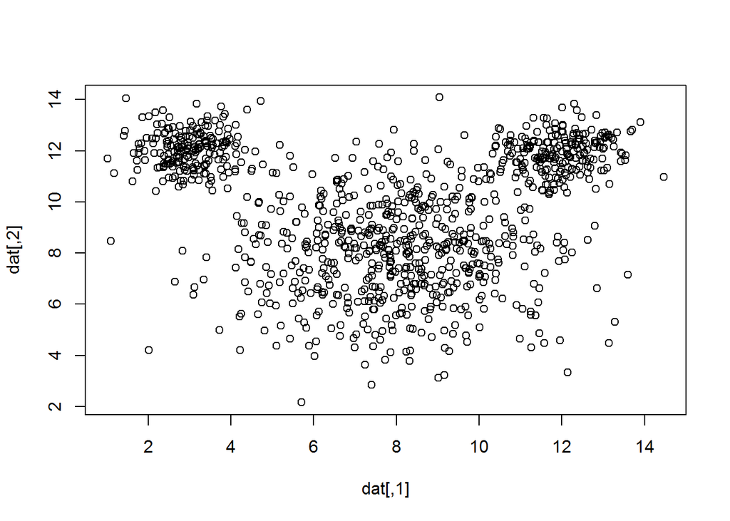

```r
set.seed(2016)
library(mvtnorm)
cv <- matrix(c(1,.1,.1,1), ncol=2)
j <- rmvnorm(200, mean = c(3,12), sigma = .5*cv)
k <- rmvnorm(600, mean = c(8,8), sigma = 4*cv)
l <- rmvnorm(200, mean = c(12,12), sigma = .5*cv)
dat <- rbind(j,k,l)
true_groups <- as.factor(c(rep("j",200),rep("k",600),rep("l",200) ))
plot(dat)
```

```r
N <- dim(dat)[1]  # number of data points
alpha <- c(0.2,0.3,0.5)  # arbitrary starting mixing parameters
mu <- matrix(  # arbitrary means
    c(5,8,
      7,8,
      9,8),
    nrow = 3, byrow=TRUE
)
sig1 <- matrix(c(1,0,0,1), nrow=2)  # three arbitrary covariance matrices
sig2 <- matrix(c(1,0,0,1), nrow=2)
sig3 <- matrix(c(1,0,0,1), nrow=2)
## write your code here


#E-STEP-----evaluate weights/responsibilities
weights<-matrix(0,nrow=1000,ncol=3)
weights[1:1000,1]<-(alpha[1]*dmvnorm(dat,mu[1,],sig1)) / (alpha[1]*dmvnorm(dat,mu[1,],sig1) +
                                                          alpha[2]*dmvnorm(dat,mu[2,],sig2) +
                                                          alpha[3]*dmvnorm(dat,mu[3,],sig3) )

weights[1:1000,2]<-(alpha[2]*dmvnorm(dat,mu[2,],sig2)) / (alpha[1]*dmvnorm(dat,mu[1,],sig1) +
                                                          alpha[2]*dmvnorm(dat,mu[2,],sig2) +
                                                          alpha[3]*dmvnorm(dat,mu[3,],sig3) )

weights[1:1000,3]<-(alpha[3]*dmvnorm(dat,mu[3,],sig3)) / (alpha[1]*dmvnorm(dat,mu[1,],sig1) +
                                                          alpha[2]*dmvnorm(dat,mu[2,],sig2) +
                                                          alpha[3]*dmvnorm(dat,mu[3,],sig3) )


#M-Step
Nk <- colSums(weights)

#new mixing parameter
alpha2<-Nk/N

#new mu
mu2<-matrix(rep(0,6),nrow=3)
mu2[1,]<- colSums(dat[1:1000,1:2]*weights[1:1000,1]) / Nk[1]
mu2[2,]<- colSums(dat[1:1000,1:2]*weights[1:1000,2]) / Nk[2]
mu2[3,]<- colSums(dat[1:1000,1:2]*weights[1:1000,3]) / Nk[3]

#new covariance matrices
cov1<-matrix(rep(0,4),nrow=2)
cov2<-matrix(rep(0,4),nrow=2)
cov3<-matrix(rep(0,4),nrow=2)

#have to use loop to figure out covariance matrix
for(i in 1:1000){
  cov1<- cov1 + weights[i,1]*((dat[i,]-mu2[1,])%*%t((dat[i,]-mu2[1.])))
  cov2<- cov2 + weights[i,2]*((dat[i,]-mu2[2,])%*%t((dat[i,]-mu2[2,])))
  cov3<- cov3 + weights[i,3]*((dat[i,]-mu2[3,])%*%t((dat[i,]-mu2[3,])))
}

newsigma1<-cov1/Nk[1]
newsigma2<-cov2/Nk[2]
newsigma3<-cov3/Nk[3]

counter<-0
while(TRUE)
{
  #attain a new mu
  mu<-mu2

  #attain new covariance matrices
  sig1<-newsigma1
  sig2<-newsigma2
  sig3<-newsigma3

  #get new mixing parameters
  alpha<-alpha2

  #LOOP IN WEIGHTS, E-STEP
  #Evaluate log-likelihood/E-step
  weights[1:1000,1]<-(alpha[1]*dmvnorm(dat,mu[1,],sig1)) / (alpha[1]*dmvnorm(dat,mu[1,],sig1) +
                                                            alpha[2]*dmvnorm(dat,mu[2,],sig2) +
                                                            alpha[3]*dmvnorm(dat,mu[3,],sig3) )

  weights[1:1000,2]<-(alpha[2]*dmvnorm(dat,mu[2,],sig2)) / (alpha[1]*dmvnorm(dat,mu[1,],sig1) +
                                                            alpha[2]*dmvnorm(dat,mu[2,],sig2) +
                                                            alpha[3]*dmvnorm(dat,mu[3,],sig3) )

  weights[1:1000,3]<-(alpha[3]*dmvnorm(dat,mu[3,],sig3)) / (alpha[1]*dmvnorm(dat,mu[1,],sig1) +
                                                            alpha[2]*dmvnorm(dat,mu[2,],sig2) +
                                                            alpha[3]*dmvnorm(dat,mu[3,],sig3) )

  #LOOP IN M-Step
  Nk <- colSums(weights) #New column sum of weights
  alpha2<-Nk/N              #New mixing parameter

  #new mu
  mu2<-matrix(rep(0,6),nrow=3)
  mu2[1,]<- colSums(dat*weights[1:1000,1]) / Nk[1]
  mu2[2,]<- colSums(dat*weights[1:1000,2]) / Nk[2]
  mu2[3,]<- colSums(dat*weights[1:1000,3]) / Nk[3]

  #new covariance matrices
  cov1<-matrix(rep(0,4),nrow=2)
  cov2<-matrix(rep(0,4),nrow=2)
  cov3<-matrix(rep(0,4),nrow=2)

  for(i in 1:1000){
    cov1<- cov1 + weights[i,1]*((dat[i,]-mu2[1,])%*%t((dat[i,]-mu2[1,])))
    cov2<- cov2 + weights[i,2]*((dat[i,]-mu2[2,])%*%t((dat[i,]-mu2[2,])))
    cov3<- cov3 + weights[i,3]*((dat[i,]-mu2[3,])%*%t((dat[i,]-mu2[3,])))
  }

  newsigma1<-cov1/Nk[1]
  newsigma2<-cov2/Nk[2]
  newsigma3<-cov3/Nk[3]

  #count the number of iterations
  counter<-counter+1

  #BREAK when convergence is reached
  if(isTRUE(all.equal(newsigma1,sig1))|
     isTRUE(all.equal(newsigma2,sig2))|
     isTRUE(all.equal(newsigma3,sig3))|
     isTRUE(all.equal(mu2,mu))         ) break
}
```